# LAB 5: LDA/QDA/RDA, kNN, Naïve Bayes

Example 2: Visualizing and classifying wines with LDA and QDA

Lluís A. Belanche, translated to R Markdown by Marta Arias

March 2020

```r
library(MASS)
library(klaR)
```

We have the results of an analysis on wines grown in a region in Italy but derived from three different cultivars. The analysis determined the quantities of 13 chemical constituents found in each of the three types of wines. The goal is to separate the three types of wines.

Let us first load the data, give appropriate names and class labels:

```r
data(wine, package="bootcluster")
dim(wine)
```

```
## [1] 178  14
```

```r
colnames(wine) <- c('Wine.type','Alcohol','Malic.acid','Ash','Alcalinity.of.ash','Magnesium','Total.phenols','Flavanoids','Nonflavanoid.phenols','Proanthocyanins','Color.intensity','Hue','OD280.OD315','Proline')
wine$Wine.type <- factor(wine$Wine.type, labels=c("Cultivar.1","Cultivar.2","Cultivar.3"))
summary(wine)
```

```
##       Wine.type     Alcohol        Malic.acid         Ash
##  Cultivar.1:59   Min.   :11.03   Min.   :0.740   Min.   :1.360
##  Cultivar.2:71   1st Qu.:12.36   1st Qu.:1.603   1st Qu.:2.210
##  Cultivar.3:48   Median :13.05   Median :1.865   Median :2.360
##                  Mean   :13.00   Mean   :2.336   Mean   :2.367
##                  3rd Qu.:13.68   3rd Qu.:3.083   3rd Qu.:2.558
##                  Max.   :14.83   Max.   :5.800   Max.   :3.230
##  Alcalinity.of.ash   Magnesium      Total.phenols     Flavanoids
##  Min.   :10.60     Min.   : 70.00   Min.   :0.980   Min.   :0.340
##  1st Qu.:17.20     1st Qu.: 88.00   1st Qu.:1.742   1st Qu.:1.205
##  Median :19.50     Median : 98.00   Median :2.355   Median :2.135
##  Mean   :19.49     Mean   : 99.74   Mean   :2.295   Mean   :2.029
##  3rd Qu.:21.50     3rd Qu.:107.00   3rd Qu.:2.800   3rd Qu.:2.875
##  Max.   :30.00     Max.   :162.00   Max.   :3.880   Max.   :5.080
##  Nonflavanoid.phenols Proanthocyanins Color.intensity       Hue
##  Min.   :0.1300       Min.   :0.410   Min.   : 1.280   Min.   :0.4800
##  1st Qu.:0.2700       1st Qu.:1.250   1st Qu.: 3.220   1st Qu.:0.7825
##  Median :0.3400       Median :1.555   Median : 4.690   Median :0.9650
##  Mean   :0.3619       Mean   :1.591   Mean   : 5.058   Mean   :0.9574
##  3rd Qu.:0.4375       3rd Qu.:1.950   3rd Qu.: 6.200   3rd Qu.:1.1200
##  Max.   :0.6600       Max.   :3.580   Max.   :13.000   Max.   :1.7100
##   OD280.OD315       Proline
##  Min.   :1.270   Min.   : 278.0
##  1st Qu.:1.938   1st Qu.: 500.5
##  Median :2.780   Median : 673.5
##  Mean   :2.612   Mean   : 746.9
##  3rd Qu.:3.170   3rd Qu.: 985.0
##  Max.   :4.000   Max.   :1680.0
```

We look at the pair-wise scatterplots with wine types color-coded:

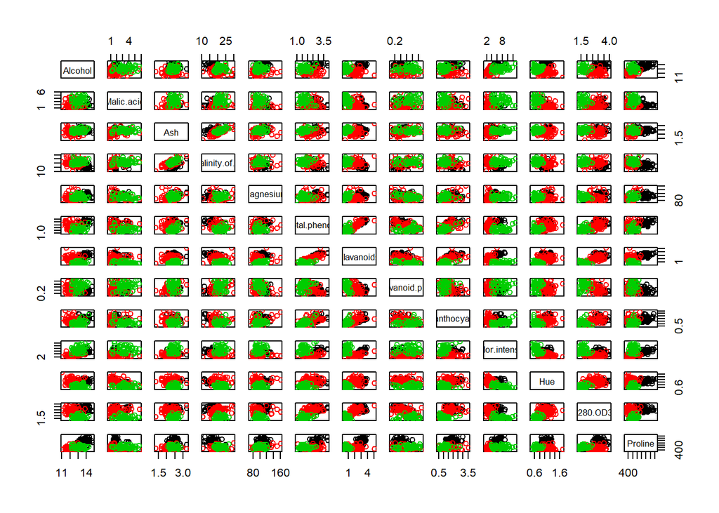

```r
plot(subset(wine,select=-Wine.type),col=unclass(wine$Wine.type))
```

For this example let’s practice a different call mode to lda(), using a formula; this is most useful when our data is in a dataframe format:

```r
(lda.model <- lda (Wine.type ~ ., data = wine))
```

```
## Call:
## lda(Wine.type ~ ., data = wine)
##
## Prior probabilities of groups:
## Cultivar.1 Cultivar.2 Cultivar.3
##  0.3314607  0.3988764  0.2696629
##
## Group means:
##             Alcohol Malic.acid      Ash Alcalinity.of.ash Magnesium
## Cultivar.1 13.74475   2.010678 2.455593          17.03729  106.3390
## Cultivar.2 12.27873   1.932676 2.244789          20.23803   94.5493
## Cultivar.3 13.15375   3.333750 2.437083          21.41667   99.3125
##            Total.phenols Flavanoids Nonflavanoid.phenols Proanthocyanins
## Cultivar.1      2.840169  2.9823729             0.290000        1.899322
## Cultivar.2      2.258873  2.0808451             0.363662        1.630282
## Cultivar.3      1.678750  0.7814583             0.447500        1.153542
##            Color.intensity       Hue OD280.OD315   Proline
## Cultivar.1        5.528305 1.0620339    3.157797 1115.7119
## Cultivar.2        3.086620 1.0562817    2.785352  519.5070
## Cultivar.3        7.396250 0.6827083    1.683542  629.8958
##
## Coefficients of linear discriminants:
##                               LD1           LD2
## Alcohol              -0.403399781  0.8717930699
## Malic.acid            0.165254596  0.3053797325
## Ash                  -0.369075256  2.3458497486
## Alcalinity.of.ash     0.154797889 -0.1463807654
## Magnesium            -0.002163496 -0.0004627565
## Total.phenols         0.618052068 -0.0322128171
## Flavanoids           -1.661191235 -0.4919980543
## Nonflavanoid.phenols -1.495818440 -1.6309537953
## Proanthocyanins       0.134092628 -0.3070875776
## Color.intensity       0.355055710  0.2532306865
## Hue                  -0.818036073 -1.5156344987
## OD280.OD315          -1.157559376  0.0511839665
## Proline              -0.002691206  0.0028529846
##
## Proportion of trace:
##    LD1    LD2
## 0.6875 0.3125
```

We can see that neither Magnesium or Proline seem useful to separate the wines; while Flavanoids and Nonflavanoid.phenols do. Ash is mainly used in the LD2.

Next we plot the projected data in the first two LDs; we can see that the discrimination is very good

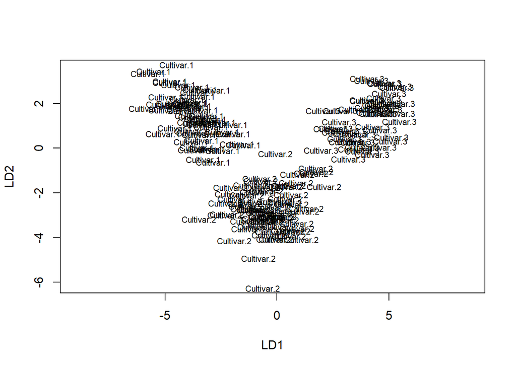

```r
plot(lda.model)
```

Alternatively, again we can do it ourselves, with more control on color and text (wine number):

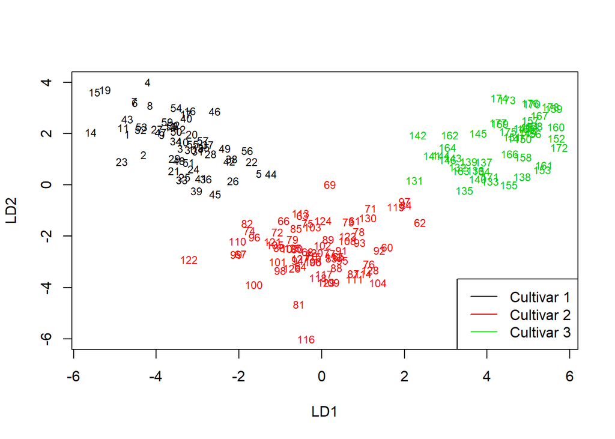

```r
wine.pred <- predict(lda.model)
plot(wine.pred$x,type="n")
text(wine.pred$x,labels=as.character(rownames(wine.pred$x)),col=as.integer(wine$Wine.type), cex=.75)
legend('bottomright', c("Cultivar 1","Cultivar 2","Cultivar 3"), lty=1, col=c('black', 'red', 'green'))
```

If need be, we can add the (projected) means to the plot:

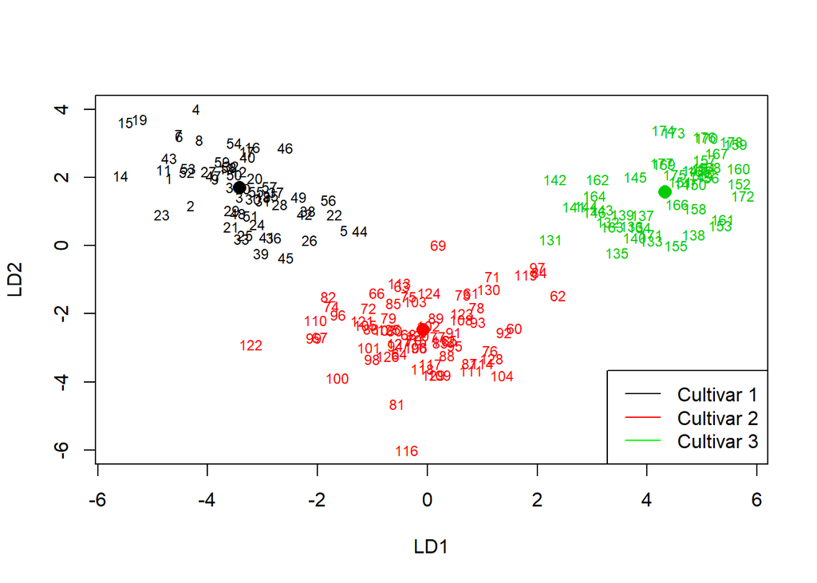

```r
plot.mean <- function (mywine)
{
  m1 <- mean(subset(wine.pred$x[,1],wine$Wine.type==mywine))
  m2 <- mean(subset(wine.pred$x[,2],wine$Wine.type==mywine))
  points(m1,m2,pch=16,cex=1.5,col=as.integer(substr(mywine, 10, 10)))
}

plot(wine.pred$x,type="n")
text(wine.pred$x,labels=as.character(rownames(wine.pred$x)),col=as.integer(wine$Wine.type), cex=.75)
legend('bottomright', c("Cultivar 1","Cultivar 2","Cultivar 3"), lty=1, col=c('black', 'red', 'green'))

plot.mean ('Cultivar.1')
plot.mean ('Cultivar.2')
plot.mean ('Cultivar.3')
```

Indeed classification is perfect (ie **training** error is **zero**):

```r
table(Truth=wine$Wine.type, Pred=wine.pred$class)
```

```
##             Pred
## Truth        Cultivar.1 Cultivar.2 Cultivar.3
##   Cultivar.1         59          0          0
##   Cultivar.2          0         71          0
##   Cultivar.3          0          0         48
```

Let us look at the prediction error (as opposed to training error). Let us switch to leave-one-out cross-validation (notice the use of update())

```r
lda.model.loocv <- update(lda.model, CV=TRUE)
head(lda.model.loocv$posterior)
```

```
##   Cultivar.1   Cultivar.2   Cultivar.3
## 1  1.0000000 2.797215e-09 2.071649e-18
## 2  0.9999996 4.380414e-07 7.695679e-17
## 3  0.9999970 3.024498e-06 1.071531e-13
## 4  1.0000000 1.251896e-12 1.095841e-16
## 5  0.8667524 1.332472e-01 3.998307e-07
## 6  1.0000000 2.236339e-11 1.017938e-17
```

The **predictive** confusion matrix is:

```r
(ct <- table(Truth=wine$Wine.type, Pred=lda.model.loocv$class))
```

```
##             Pred
## Truth        Cultivar.1 Cultivar.2 Cultivar.3
##   Cultivar.1         59          0          0
##   Cultivar.2          1         69          1
##   Cultivar.3          0          0         48
```

So: 2 mistakes (on 178 observations): 1.12% error

```r
chisq.test(ct)
```

```
##
##  Pearson's Chi-squared test
##
## data:  ct
## X-squared = 344.48, df = 4, p-value < 2.2e-16
```

The p-value of the $\chi^2$ test is indeed tiny.

Now let us turn to performing the more general Quadratic Discriminant Analysis (QDA); in terms of `R` we just replace `lda` by `qda`. Problems may arise as you saw in class if for some class there are fewer (or equal) observations than dimensions (luckily this is not the case for our wine data), so we proceed with general QDA.

```r
(qda.model <- qda (Wine.type ~ ., data = wine))
```

```
## Call:
## qda(Wine.type ~ ., data = wine)
##
## Prior probabilities of groups:
## Cultivar.1 Cultivar.2 Cultivar.3
##  0.3314607  0.3988764  0.2696629
##
## Group means:
##             Alcohol Malic.acid      Ash Alcalinity.of.ash Magnesium
## Cultivar.1 13.74475   2.010678 2.455593          17.03729  106.3390
## Cultivar.2 12.27873   1.932676 2.244789          20.23803   94.5493
## Cultivar.3 13.15375   3.333750 2.437083          21.41667   99.3125
##            Total.phenols Flavanoids Nonflavanoid.phenols Proanthocyanins
## Cultivar.1      2.840169  2.9823729             0.290000        1.899322
## Cultivar.2      2.258873  2.0808451             0.363662        1.630282
## Cultivar.3      1.678750  0.7814583             0.447500        1.153542
##            Color.intensity       Hue OD280.OD315   Proline
## Cultivar.1        5.528305 1.0620339    3.157797 1115.7119
## Cultivar.2        3.086620 1.0562817    2.785352  519.5070
## Cultivar.3        7.396250 0.6827083    1.683542  629.8958
```

**There is no projection this time (because projection is a linear operator and the QDA boundaries are quadratic).**

Let’s have a look at classification using LOOCV:

```r
qda.model.loocv <- qda (Wine.type ~ ., data = wine, CV=TRUE)
head(qda.model.loocv$posterior)
```

```
##   Cultivar.1   Cultivar.2    Cultivar.3
## 1  1.0000000 8.920821e-12 4.507563e-103
## 2  1.0000000 1.769818e-09  4.454565e-92
## 3  0.9999999 8.114981e-08 6.097512e-110
## 4  1.0000000 3.912182e-19 1.829719e-137
## 5  0.9995416 4.583964e-04  4.452314e-53
## 6  1.0000000 4.786107e-18 1.777360e-134
```

The contingency table:

```r
(ct <- table(Truth=wine$Wine.type, Pred=qda.model.loocv$class))
```

```
##             Pred
## Truth        Cultivar.1 Cultivar.2 Cultivar.3
##   Cultivar.1         59          0          0
##   Cultivar.2          1         70          0
##   Cultivar.3          0          0         48
```

There is an improvement: 1 mistake (on 178 observations): 0.56% error

```r
chisq.test(ct) # a slightly better model
```

```
##
##  Pearson's Chi-squared test
##
## data:  ct
## X-squared = 350.57, df = 4, p-value < 2.2e-16
```

The $\chi^2$ statistic is slightly better, too.

It would be nice to find out which is the “stubborn” wine: it is a wine of ‘Cultivar.2’ classified as ‘Cultivar.1’. Maybe there is something strange with this wine … (maybe an expert can tell!)

Finally, for the sake of illustration, let’s use RDA (the *regularized* version). The `rda()` function is in the `klaR` package as well. By default, it uses 10-fold cross-validation to determine the values of the hyperparameters $\lambda,\gamma$. We chose to change it to 20-cv to make it closer to LOOCV above.

```r
set.seed(1)
(rda.model.cv <- rda (Wine.type ~ ., data = wine, fold=20))
```

```
## Call:
## rda(formula = Wine.type ~ ., data = wine, fold = 20)
##
## Regularization parameters:
##      gamma     lambda
## 0.92320825 0.06472842
##
## Prior probabilities of groups:
## Cultivar.1 Cultivar.2 Cultivar.3
##  0.3314607  0.3988764  0.2696629
##
## Misclassification rate:
##        apparent: 25.843 %
## cross-validated: 26.479 %
```